# Premiere League Stats Visualization

Takdir Zulhaq Dessiaming

2022-07-22

# Introduction

[figure not shown]

The Premier League is the organising body of the Premier League with responsibility for the competition, its Rule Book and the centralised broadcast and other commercial rights.

Each individual club is independent, working within the rules of football, as defined by the Premier League, The FA, UEFA and FIFA, as well as being subject to English and European law.

Each of the 20 clubs are a Shareholder in the Premier League. Consultation is at the heart of the Premier League and Shareholder meetings are the ultimate decision-making forum for Premier League policy and are held at regular intervals during the course of the season.

The Premier League AGM takes place at the close of each season, at which time the relegated clubs transfer their shares to the clubs promoted into the Premier League from the Football League Championship.

*Note : Premier League is the Main League/First Division of England Football League*

On the previous post, we have analyzed the data about premier league stats. There are 2 dataset from the source, `stats.csv` and `results.csv`. What we have here is `results.csv`, and we will continue our analysis on the previous post, but we will also add a visualization, to make it more easy to interpretation.

**The main goal we have here is, to know :** **- What the top 10 club with the most home or away goal** **- Further analysis of Manchester United** **- Further analysis on Chelsea and Manchester City (on the previous post)** **- Team that are eligible to play in Champions League**

# Data Preprocessing

This is the step we prepare the data before analysis.

```r
# Prepare the library to use analysis below

library(scales)
library(dplyr)
```

```r
library(ggplot2)
library(tidyr)
```

## Import Data

The first thing we should do is import the data to our notebook.

```r
results <- read.csv("results.csv")
results
```

| home_team | away_team | home_goals | away_goals | result | season |
| --- | --- | --- | --- | --- | --- |
| Sheffield United | Liverpool | 1 | 1 | D | 2006-2007 |
| Arsenal | Aston Villa | 1 | 1 | D | 2006-2007 |
| Everton | Watford | 2 | 1 | H | 2006-2007 |
| Newcastle United | Wigan Athletic | 2 | 1 | H | 2006-2007 |
| Portsmouth | Blackburn Rovers | 3 | 0 | H | 2006-2007 |
| Reading | Middlesbrough | 3 | 2 | H | 2006-2007 |
| West Ham United | Charlton Athletic | 3 | 1 | H | 2006-2007 |
| Bolton Wanderers | Tottenham Hotspur | 2 | 0 | H | 2006-2007 |
| Manchester United | Fulham | 5 | 1 | H | 2006-2007 |
| Chelsea | Manchester City | 3 | 0 | H | 2006-2007 |

[output cut: 4550 more lines]

As we can see, there are 6 columns, with 4560 rows of data we have. This data will we use to analyze and explore the data.

The data we have, there are :

1. home_team = The team that they play as **the host/Home (it’s Stadium)**
2. away_team = The team that they play as **Away (Opponent’s Stadium)**
3. home_goals = The team that they score as the host/Home
4. away_goals = the team that they score as the Away
5. result = The Match Result, **D = Draw, H = Home Team win, A = Away Team win**
6. season = Season of the Match

## Data Cleansing

```r
str(results)
```

```
## 'data.frame':    4560 obs. of  6 variables:
##  $ home_team : chr  "Sheffield United" "Arsenal" "Everton" "Newcastle United" ...
##  $ away_team : chr  "Liverpool" "Aston Villa" "Watford" "Wigan Athletic" ...
##  $ home_goals: num  1 1 2 2 3 3 3 2 5 3 ...
##  $ away_goals: num  1 1 1 1 0 2 1 0 1 0 ...
##  $ result    : chr  "D" "D" "H" "H" ...
##  $ season    : chr  "2006-2007" "2006-2007" "2006-2007" "2006-2007" ...
```

Let’s check missing value to make sure.

### Check Missing Value

```r
colSums(is.na(results))
```

```
##  home_team  away_team home_goals away_goals     result     season
##          0          0          0          0          0          0
```

There’s no missing value, that’s good. We can continue now.

### Check Data Type

The data contains 2 type of data, `num` and `chr`. For the analysis, we can change the data type for “home_team”, “away_team”, “result”, and “season” columns. Why? because there is data repeating. So we have to change the data type to factor(category) for ease data analysis.

```r
results$home_team <- as.factor(results$home_team)
results$away_team <- as.factor(results$away_team)
results$result <- as.factor(results$result)
results$season <- as.factor(results$season)
str(results)
```

```
## 'data.frame':    4560 obs. of  6 variables:
##  $ home_team : Factor w/ 39 levels "AFC Bournemouth",..: 29 2 15 24 26 28 37 7 22 12 ...
##  $ away_team : Factor w/ 39 levels "AFC Bournemouth",..: 20 3 35 38 5 23 11 34 16 21 ...
##  $ home_goals: num  1 1 2 2 3 3 3 2 5 3 ...
##  $ away_goals: num  1 1 1 1 0 2 1 0 1 0 ...
##  $ result    : Factor w/ 3 levels "A","D","H": 2 2 3 3 3 3 3 3 3 3 ...
##  $ season    : Factor w/ 12 levels "2006-2007","2007-2008",..: 1 1 1 1 1 1 1 1 1 1 ...
```

Now all the data types is correct for each columns.

# EDA and Visualization

EDA stands for (Exploratory Data Analysis), it means we will explore the data to find something interesting.

```r
summary(results)
```

```
##              home_team                away_team      home_goals
##  Arsenal          : 228   Arsenal          : 228   Min.   :0.000
##  Chelsea          : 228   Chelsea          : 228   1st Qu.:1.000
##  Everton          : 228   Everton          : 228   Median :1.000
##  Liverpool        : 228   Liverpool        : 228   Mean   :1.543
##  Manchester City  : 228   Manchester City  : 228   3rd Qu.:2.000
##  Manchester United: 228   Manchester United: 228   Max.   :9.000
##  (Other)          :3192   (Other)          :3192
##    away_goals    result         season
##  Min.   :0.000   A:1288   2006-2007: 380
##  1st Qu.:0.000   D:1164   2007-2008: 380
##  Median :1.000   H:2108   2008-2009: 380
##  Mean   :1.144            2009-2010: 380
##  3rd Qu.:2.000            2010-2011: 380
##  Max.   :7.000            2011-2012: 380
##                           (Other)  :2280
```

📌 Short Summary :

- The average goals scored at **Home is higher** than Away
- The highest home team score **(home goal)** in one match is **9 goal**!
  - or we can say, the highest home team win the game with 9 goal!
- The highest away team score **(away goal)** in one match is **7 goal**!
  - or we can say, the highest away team win the game with 7 goal!
- There are **2108 Home win**, **1164 Draw**, and **1288 Away win**. Looks like the teams in Premier League is strong as Home team!
- There are **380 match** per season (12 season)

## Case Questions

Now let’s explore the data more, and ask some question or we can find the detail about the summary above!

### 1. What team with the Top 10 Home Goal over 12 season?

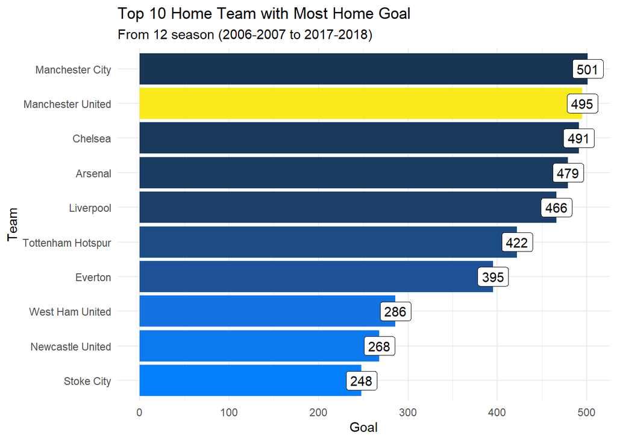

```r
top10_home <- aggregate(data =results, x = home_goals ~ home_team, FUN = sum )
top10_home_order <- top10_home[order(top10_home$home_goals, decreasing = T),][1:10,]

ggplot(data = top10_home_order, mapping = aes(x = home_goals , y = reorder(home_team, home_goals))) +
  geom_col(aes(fill=home_goals), show.legend = F) +
  geom_col(data = top10_home_order[2,],fill="#faeb1e") +
  scale_fill_continuous(low = "#037ffc", high = "#183654") +    #The color we use HEX Code of color
  geom_label(aes(label=home_goals)) +
  labs(
    title = "Top 10 Home Team with Most Home Goal",
    subtitle = "From 12 season (2006-2007 to 2017-2018)",
    y = "Team",
    x = "Goal"
  ) +
  theme_minimal()
```

📌 Insight :

- **Manchester City** is the **most home goal**, just 6 goal differ from Manchester United who had the most win.
- It looks like **Manchester United with the most win** has **a lot of goal** too.

### 2. What team with the Top 10 Away Goal over 12 season?

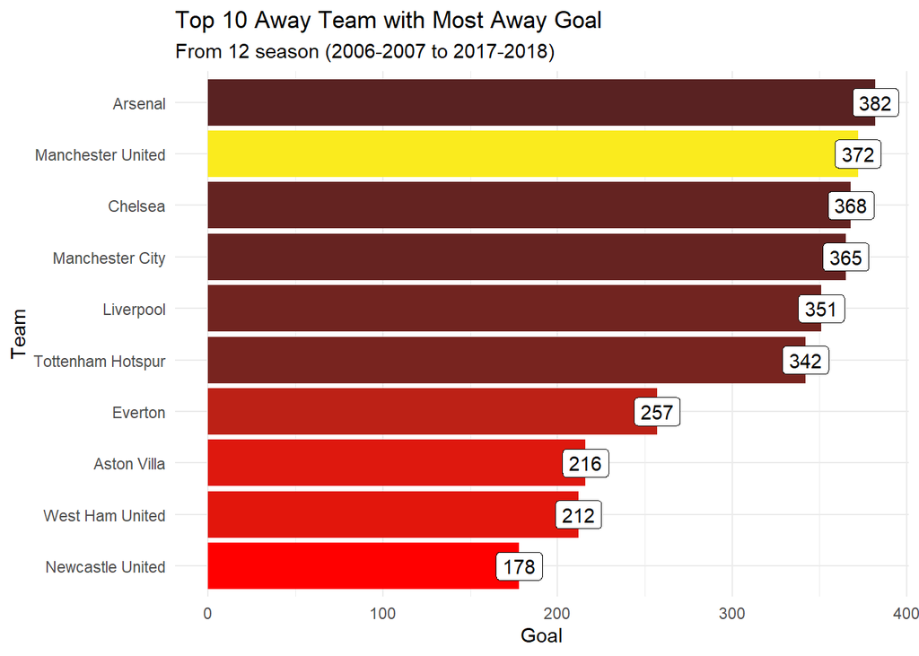

```r
top10_away <- aggregate(data =results, x = away_goals ~ away_team, FUN = sum )
top10_away_order <- top10_away[order(top10_away$away_goals, decreasing = T),][1:10,]

ggplot(data = top10_away_order, mapping = aes(x = away_goals , y = reorder(away_team, away_goals))) +
  geom_col(aes(fill=away_goals), show.legend = F) +
  geom_col(data = top10_away_order[2,],fill="#faeb1e") +
  scale_fill_continuous(low = "#ff0000", high = "#592222") +     #The color we use HEX Code of color
  geom_label(aes(label=away_goals)) +
  labs(
    title = "Top 10 Away Team with Most Away Goal",
    subtitle = "From 12 season (2006-2007 to 2017-2018)",
    y = "Team",
    x = "Goal"
  ) +
  theme_minimal()
```

### 3. How Manchester United Match Result over 12 season?

Let’s explore more about Manchester United. We see the average from match result of Manchester United, the most win team over 12 season!

```r
mu_h <- results[results$home_team == "Manchester United",]
mu_h$home_team <-  droplevels(mu_h$home_team)

muh_result <-  as.data.frame(table(mu_h$result))

mu_a <- results[results$away_team == "Manchester United",]
mu_a$away_team <-  droplevels(mu_a$away_team)

mua_result <- as.data.frame(table(mu_a$result))

colnames(muh_result)[colnames(muh_result)=="Freq"] = "Home Total"
colnames(mua_result)[colnames(mua_result)=="Freq"] = "Away Total"


muha_join <- left_join(muh_result, mua_result)
muha_join <- pivot_longer(data = muha_join,
                    cols = c("Home Total", "Away Total"))
muha_join
```

| Var1 | name | value |
| --- | --- | --- |
| A | Home Total | 26 |
| A | Away Total | 119 |
| D | Home Total | 31 |
| D | Away Total | 58 |
| H | Home Total | 171 |
| H | Away Total | 51 |

Now we visualize it!

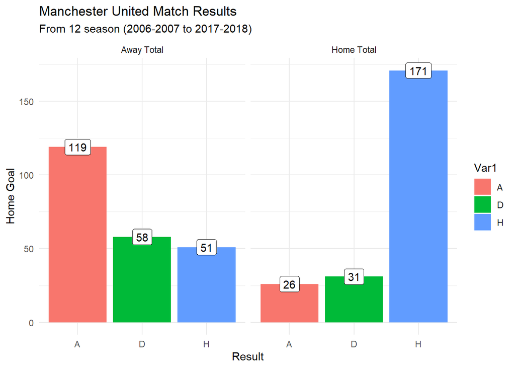

```r
ggplot(data = muha_join, mapping = aes(x = Var1, y = value, fill = Var1)) +
  geom_col()  +
  geom_label(aes(label=value), fill = "white") +
  facet_wrap(~ name) +
  labs(
    title='Manchester United Match Results',
    subtitle='From 12 season (2006-2007 to 2017-2018)',
    x = 'Result',
    y = 'Home Goal'
  ) +
  theme_minimal()
```

🟥**IMPORTANT NOTE :**🟥

- AS **AWAY TEAM**
  - **A = WIN**
  - D = DRAW
  - H = LOSS
- AS **HOME TEAM**
  - **H = WIN**
  - D = DRAW
  - A = LOSS

📌 Insight :

- Manchester United as Home Team, have a **winning total higher** than as Away Team.
- Manchester United as Home Team, their winning total is **far higher** than Loss and Draw.
- It’s same for as Away Team, also have high winning average, but lower than as Home Team.

### 4. Manchester United Goal Performance

What about their goal per season? Let’s see!

```r
mu_home <- results[results$home_team == "Manchester United" & results$result== "H",]
mu_home <- aggregate(data = mu_home, x = home_goals ~ season, FUN = sum)

mu_away <- results[results$away_team == "Manchester United" & results$result== "A",]
mu_away <- aggregate(data = mu_away, x = away_goals ~ season , FUN = sum)

# There's 2 dataframes, MU for home and MU for away team. For ease to head to head each other, we try to join them using left join

join_mu <- left_join(mu_home, mu_away)
join_mu <- pivot_longer(data = join_mu,
                           cols = c("home_goals", "away_goals"))
join_mu
```

| season | name | value |
| --- | --- | --- |
| 2006-2007 | home_goals | 44 |
| 2006-2007 | away_goals | 32 |
| 2007-2008 | home_goals | 46 |
| 2007-2008 | away_goals | 24 |
| 2008-2009 | home_goals | 41 |
| 2008-2009 | away_goals | 21 |
| 2009-2010 | home_goals | 49 |
| 2009-2010 | away_goals | 31 |
| 2010-2011 | home_goals | 47 |
| 2010-2011 | away_goals | 15 |

[output cut: 14 more lines]

Now, we visualize it!

### 5. Manchester United Home and Away Goal

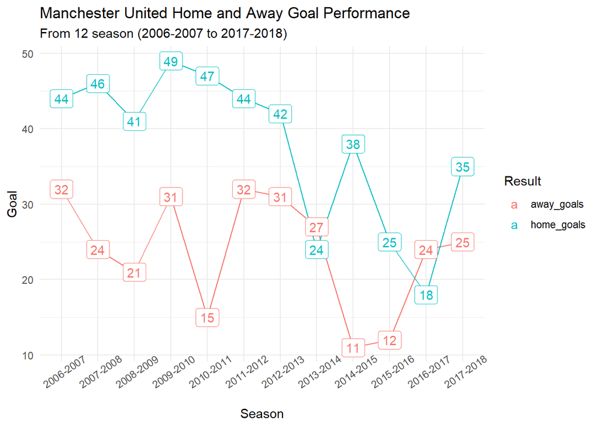

```r
ggplot(data = join_mu, mapping = aes(x = season, y = value, group = name, col = name)) +
  geom_line() +
  geom_point() +
  geom_label(aes(label=value)) +
  labs(
    title='Manchester United Home and Away Goal Performance',
    subtitle='From 12 season (2006-2007 to 2017-2018)',
    x = 'Season',
    y = 'Goal',
    col = 'Result'
  ) +

  theme_minimal() +
  theme(axis.text.x = element_text(angle = 35))
```

📌 Insight :

- There is a **fluctuating** both home and away goal.
- **Highest home goal** in season **2009-2010**. The **Lowest home goal** in **2016-2017**.
- **Highest away goal** in season **2006-2007 and 2011-2012**. The **Lowest away goal** in **2014-2015**.

### 6. Chelsea vs Manchester City Home and Away Goal

We try to find their Goal total.

```r
# FIND THEIR GOAL TOTAL

# CHELSEA AS HOME AND AWAY TEAM SUBSETTING

c_home <- results[results$home_team == "Chelsea" & results$result == "H",]
c_home <- aggregate(data = c_home, x = home_goals ~ season + home_team, FUN = sum)

c_away <- results[results$away_team == "Chelsea" & results$result == "A",]
c_away <- aggregate(data = c_away, x = away_goals ~ season +away_team , FUN = sum)

c_result <- left_join(c_home, c_away)
c_result <- pivot_longer(data = c_result,
                           cols = c("home_goals", "away_goals"))

# MANCHESTER CITY AS HOME AND AWAY TEAM SUBSETTING

mc_home <- results[results$home_team == "Manchester City" & results$result == "H",]
mc_home <-  aggregate(data = mc_home, x = home_goals ~ season+ home_team , FUN = sum)

mc_away <- results[results$away_team == "Manchester City" & results$result == "A",]
mc_away <-  aggregate(data = mc_away, x = away_goals ~ season+ away_team , FUN = sum)

mc_result <- left_join(mc_home, mc_away)
mc_result <- pivot_longer(data = mc_result,
                           cols = c("home_goals", "away_goals"))

cmc_result <- full_join(c_result,mc_result)
cmc_result <- cmc_result[,-2]
colnames(cmc_result)[colnames(cmc_result)=="away_team"] = "team"


cmc_result <- spread(data = cmc_result, name, value)
cmc_result <- pivot_longer(data = cmc_result,
                           cols = c("away_goals", "home_goals"))
colnames(cmc_result)[colnames(cmc_result)=="name"] = "goal"
head(cmc_result)
```

| season | team | goal | value |
| --- | --- | --- | --- |
| 2006-2007 | Chelsea | away_goals | 23 |
| 2006-2007 | Chelsea | home_goals | 28 |
| 2006-2007 | Manchester City | away_goals | 11 |
| 2006-2007 | Manchester City | home_goals | 9 |
| 2007-2008 | Chelsea | away_goals | 23 |
| 2007-2008 | Chelsea | home_goals | 29 |

Now for visualize!

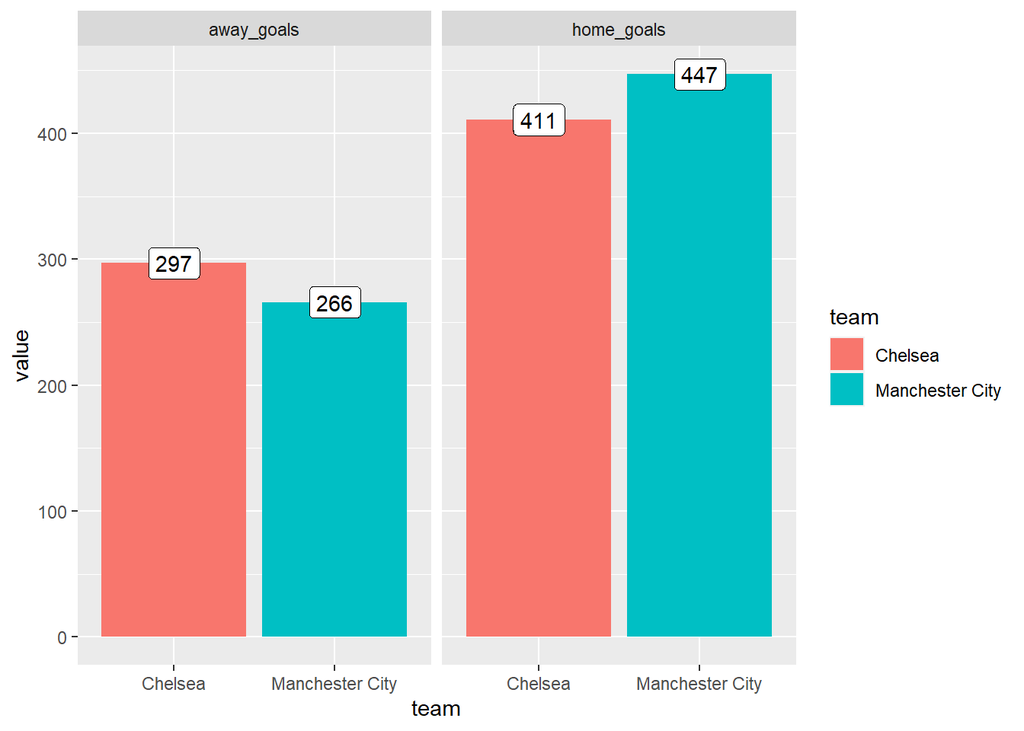

```r
cmc_agg <- aggregate( value ~ goal + team  , data = cmc_result, FUN = sum)

ggplot(data = cmc_agg, aes(x = team, y = value)) +
  geom_col(aes(fill = team), position = "dodge") +
  facet_wrap(~ goal) +

  geom_label(aes(label=value))
```

📌 Insight :

- Both team have **a slight difference** in the number of goals. Let’s just calculate it.

```r
chelsea <- 297 + 411
mc <-  266 + 447

chelsea
```

```
## [1] 708
```

```r
mc
```

```
## [1] 713
```

- We can see that **Manchester City has more goal than Chelsea**, but still why Chelsea has more win?

### 7. Chelsea vs Manchester City Match Result

As we can see that Manchester City still has more goals than Chelsea. To make sure why Chelsea has more win, let’s look for **their match result**.

```r
# FIND THEIR MATCH RESULT

# CHELSEA AND MANCHESTER CITY AS HOME TEAM SUBSETTING

c_mc <- results[results$home_team == "Chelsea" | results$home_team == "Manchester City",]
c_mc$home_team <-  droplevels(c_mc$home_team)
c_mc_result <-  as.data.frame(table(c_mc$home_team, c_mc$result))

colnames(c_mc_result)[colnames(c_mc_result)=="Var2"] = "Result"
colnames(c_mc_result)[colnames(c_mc_result)=="Freq"] = "Home Team"

# CHELSEA AND MANCHESTER CITY AS AWAY TEAM SUBSETTING

c_mc_a <- results[results$away_team == "Chelsea" | results$away_team == "Manchester City",]
c_mc_a$away_team <-  droplevels(c_mc_a$away_team)
c_mca_result <-  as.data.frame(table(c_mc_a$away_team, c_mc_a$result))

colnames(c_mca_result)[colnames(c_mca_result)=="Var2"] = "Result"
colnames(c_mca_result)[colnames(c_mca_result)=="Freq"] = "Away Team"


# CHELSEA AND MANCHESTER CITY JOINING HOME AND AWAY TEAM SUBSETTING

cmc_join <- left_join(c_mc_result, c_mca_result)
cmc_join <- pivot_longer(data = cmc_join,
                    cols = c("Home Team", "Away Team"))

cmc_agg <- aggregate(cmc_join, value ~  Var1 + Result + name , FUN = sum)
cmc_agg
```

| Var1 | Result | name | value |
| --- | --- | --- | --- |
| Chelsea | A | Away Team | 123 |
| Manchester City | A | Away Team | 100 |
| Chelsea | D | Away Team | 49 |
| Manchester City | D | Away Team | 56 |
| Chelsea | H | Away Team | 56 |
| Manchester City | H | Away Team | 72 |
| Chelsea | A | Home Team | 23 |
| Manchester City | A | Home Team | 35 |
| Chelsea | D | Home Team | 52 |
| Manchester City | D | Home Team | 37 |

[output cut: 2 more lines]

We have result both of these two team. Now we visualize it.

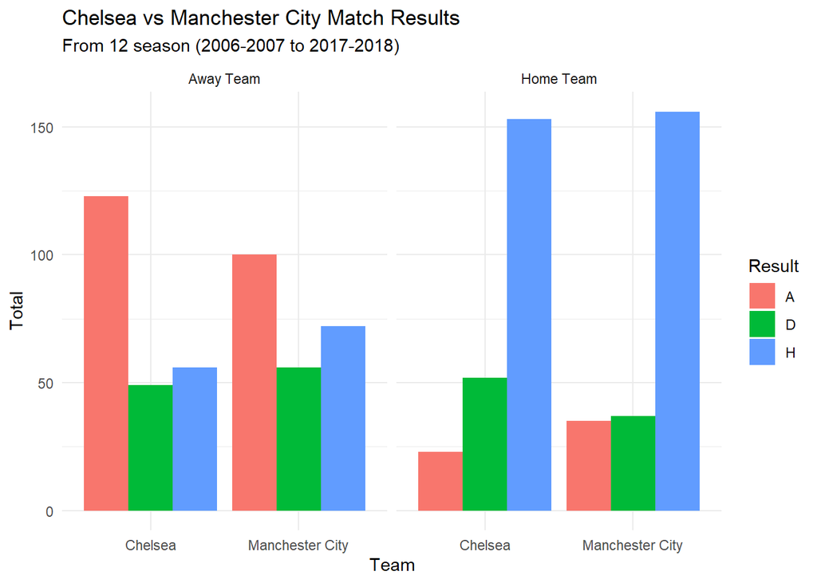

```r
ggplot(data = cmc_agg, mapping = aes(x = Var1, y = value, fill = Result))+
  geom_col(aes(fill = Result), position = "dodge", ) +
  facet_wrap(~name) +
  labs(
  title='Chelsea vs Manchester City Match Results ',
  subtitle='From 12 season (2006-2007 to 2017-2018)',
  x = 'Team',
  y = 'Total'
  ) +
  theme_minimal()
```

🟥**IMPORTANT NOTE :**🟥

- AS **AWAY TEAM**
  - **A = WIN**
  - D = DRAW
  - H = LOSS
- AS **HOME TEAM**
  - **H = WIN**
  - D = DRAW
  - A = LOSS

📌 Insight :

- As Away Team, **Chelsea has more goals** than Manchester City. And then, **Manchester City has more loss** than Chelsea.
- As Home Team, there is **a slight difference in goals**, but Manchester City has more a little. And then, **Manchester City has more loss** than Chelsea.

### 8. Standings for Champions League qualification

For another exploration, as the previous post, we say that each team have to be the top 5 to qualified to Champions League. Let’s see who will be get in season 2017-2018!

Before that, we have to know Premier League Standings point rules : - Three points are awarded for a win, - 0ne point for a draw and - None for a defeat - The team with the most points at the end of the season winning the Premier League title.

So, we will make a simple standings based on our data, our data contains result match over 12 season. Let’s just take 2017-2018 for our analysis.

```r
# HOME

clas_h <- results[results$season =="2017-2018",]
clas_h <- clas_h[,c("home_team","home_goals","result","season")]
clas_h <- as.data.frame.matrix(table(clas_h$home_team,clas_h$result))

clas_h$point <-  (clas_h$D * 1) + (clas_h$H * 3)
clas_h <- clas_h[order(clas_h$point, decreasing = TRUE),]


clas_h <- cbind(team = rownames(clas_h), clas_h)
rownames(clas_h) <- NULL

# AWAY

clas_a <- results[results$season =="2017-2018",]
clas_a <- clas_a[,c("away_team","away_goals","result","season")]
clas_a <- as.data.frame.matrix(table(clas_a$away_team,clas_a$result))

clas_a$point <-  (clas_a$D * 1) + (clas_a$A * 3)
clas_a <- clas_a[order(clas_a$point, decreasing = TRUE),]



clas_a <- cbind(team = rownames(clas_a), clas_a)
rownames(clas_a) <- NULL

clas_h
```

| team | A | D | H | point |
| --- | --- | --- | --- | --- |
| Manchester City | 1 | 2 | 16 | 50 |
| Arsenal | 2 | 2 | 15 | 47 |
| Manchester United | 2 | 2 | 15 | 47 |
| Liverpool | 0 | 7 | 12 | 43 |
| Tottenham Hotspur | 2 | 4 | 13 | 43 |
| Chelsea | 4 | 4 | 11 | 37 |
| Everton | 5 | 4 | 10 | 34 |
| Brighton and Hove Albion | 4 | 8 | 7 | 29 |
| Newcastle United | 7 | 4 | 8 | 28 |
| Leicester City | 6 | 6 | 7 | 27 |

[output cut: 29 more lines]

```r
clas_a
```

| team | A | D | H | point |
| --- | --- | --- | --- | --- |
| Manchester City | 16 | 2 | 1 | 50 |
| Manchester United | 10 | 4 | 5 | 34 |
| Tottenham Hotspur | 10 | 4 | 5 | 34 |
| Chelsea | 10 | 3 | 6 | 33 |
| Liverpool | 9 | 5 | 5 | 32 |
| Burnley | 7 | 7 | 5 | 28 |
| Leicester City | 5 | 5 | 9 | 20 |
| AFC Bournemouth | 4 | 6 | 9 | 18 |
| Crystal Palace | 4 | 6 | 9 | 18 |
| Southampton | 3 | 8 | 8 | 17 |

[output cut: 29 more lines]

We have standings, but it’s not the final. It’s just standings for Home and Away team. We have 2 dataframes now, the we have to join them!

```r
stands <- full_join(clas_h,clas_a, "team")
stands$total_points <- stands$point.x + stands$point.y

stands <- stands[order(stands$total_points, decreasing = T),]
row.names(stands) <-  NULL

stands <- stands[,-c(2:9)]

stands <- stands[apply(stands!=0, 1, all),]
stands
```

|  | team | total_points |
| --- | --- | --- |
| 1 | Manchester City | 100 |
| 2 | Manchester United | 81 |
| 3 | Tottenham Hotspur | 77 |
| 4 | Liverpool | 75 |
| 5 | Chelsea | 70 |
| 6 | Arsenal | 63 |
| 7 | Burnley | 54 |
| 8 | Everton | 49 |
| 9 | Leicester City | 47 |
| 10 | Newcastle United | 44 |

[output cut: 10 more lines]

This is the final Standings now. Let’s Visualize it.

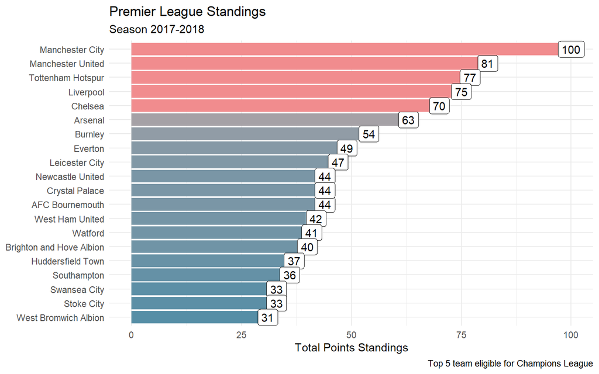

```r
ggplot(data = stands, aes(x = total_points, y = reorder(team , total_points))) +
  geom_col( position = "dodge") +
  geom_col(aes(fill = total_points), show.legend = FALSE) +
  geom_col(data = stands[1:5,], fill = "#f18c8e") +
  scale_fill_continuous(low = "#568ea6", high = "#f0b7a4") +
  geom_label(aes(label=total_points)) +
   labs(title = "Premier League Standings",
        subtitle = "Season 2017-2018",
        caption = "Top 5 team eligible for Champions League",
        x = "Total Points Standings",
        y = NULL) +
  theme(legend.position = "top", # untuk mengubah posisi legend
        plot.title.position = "plot") + # untuk mengubah posisi judul plot
  theme_minimal()
```

📌 Insight :

- Looks like Manchester City win the Premier League title this time!
- The team that are eligible for Champions League are :
  - Manchester City (Of course)
  - Manchester United
  - Tottenham Hotspur
  - Liverpool
  - Chelsea
- Congrats!

# Conclusion

Based on analysis above, we find that :